# STA206Final

Ojas Upadhye, Maxwell Capron, Skylar Calandra

2025-12-04

Load dataset, convert categorical variables to factors and plot histograms and piecharts.

```r
plasma = read.table("Plasma.txt",header=TRUE)

sapply(plasma,class)
```

```
##         AGE         SEX    SMOKSTAT    QUETELET      VITUSE    CALORIES
##   "integer" "character" "character"   "numeric" "character"   "numeric"
##         FAT       FIBER     ALCOHOL CHOLESTEROL    BETADIET     RETDIET
##   "numeric"   "numeric"   "numeric"   "numeric"   "integer"   "integer"
##  BETAPLASMA   RETPLASMA
##   "integer"   "integer"
```

```r
plasma$SEX <- as.factor(plasma$SEX)
plasma$SMOKSTAT <- as.factor(plasma$SMOKSTAT)
plasma$VITUSE <- as.factor(plasma$VITUSE)
sapply(plasma,class)
```

```
##         AGE         SEX    SMOKSTAT    QUETELET      VITUSE    CALORIES
##   "integer"    "factor"    "factor"   "numeric"    "factor"   "numeric"
##         FAT       FIBER     ALCOHOL CHOLESTEROL    BETADIET     RETDIET
##   "numeric"   "numeric"   "numeric"   "numeric"   "integer"   "integer"
##  BETAPLASMA   RETPLASMA
##   "integer"   "integer"
```

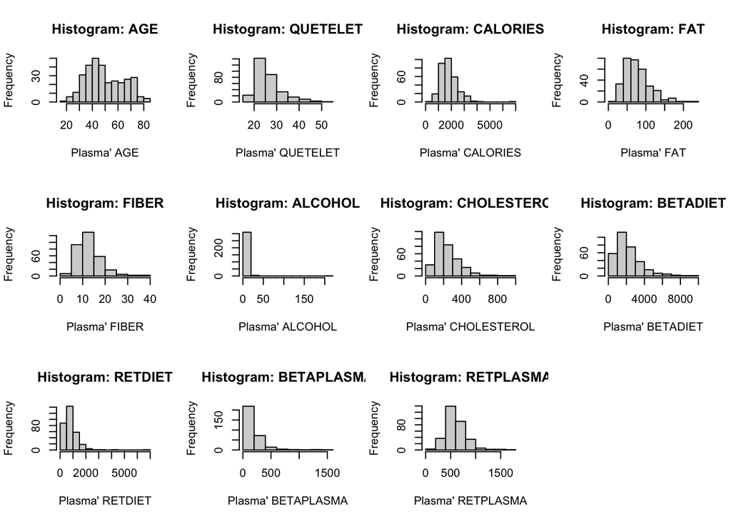

```r
par(mfrow = c(3,4))


for(i in 1:14) {
  if (i != 2 && i != 3 && i!= 5 ) {
hist(plasma[, i], main=paste("Histogram:", names(plasma)[i]), xlab = paste('Plasma\'', names(plasma)[i]))}}



par(mfrow = c(1,3))
```

```r
n <- nrow(plasma)
vals =
lbls <- c('FEMALE','MALE')
pct <- round(100*table(plasma$SEX)/n)
lab <- paste(lbls,pct)
lab <- paste(lab,'%',sep='')
lab
```

```
## [1] "FEMALE 87%" "MALE 13%"
```

```r
pie(table(plasma$SEX),labels=lab,col=c('blue','purple','green','yellow','orange'),
main='Sex: pie chart with percentage')


n <- nrow(plasma)
vals =
lbls <- c('FORMER','NEVER','CURRENT')
pct <- round(100*table(plasma$SMOKSTAT)/n)
lab <- paste(lbls,pct)
lab <- paste(lab,'%',sep='')
lab
```

```
## [1] "FORMER 14%"  "NEVER 37%"   "CURRENT 50%"
```

```r
pie(table(plasma$SMOKSTAT),labels=lab,col=c('blue','purple','green','yellow','orange'),
main='SMOKSTAT: pie chart with percentage')


n <- nrow(plasma)
vals =
lbls <- c('OFTEN','NOT OFTEN','NO')
pct <- round(100*table(plasma$VITUSE)/n)
lab <- paste(lbls,pct)
lab <- paste(lab,'%',sep='')
lab
```

```
## [1] "OFTEN 35%"     "NOT OFTEN 26%" "NO 39%"
```

[figure not shown]

```r
pie(table(plasma$VITUSE),labels=lab,col=c('blue','purple','green','yellow','orange'),
main='VITAMIN USE: pie chart')
```

TRANSFORMATIONS:

Exclude observations for MALE patients and perform log transform on vars with non-normal distributions.

```r
plasma = subset(plasma,SEX != "MALE")

plasma$logBETAPLASMA = log(plasma$BETAPLASMA+1)
plasma$logRETDIET = log(plasma$RETDIET+1)
plasma$logQUETELET = log(plasma$QUETELET+1)
plasma$logBETADIET = log(plasma$BETADIET+1)
plasma$logALCOHOL = log(plasma$ALCOHOL+1)


plasma$CaloriesFat = (9*plasma$FAT)/(plasma$CALORIES)
plasma$CholesterolCal = (plasma$CHOLESTEROL)/(plasma$CALORIES)
plasma$FiberCalories = (plasma$FIBER)/(plasma$CALORIES)
```

After the transformations, we get the following distributions.

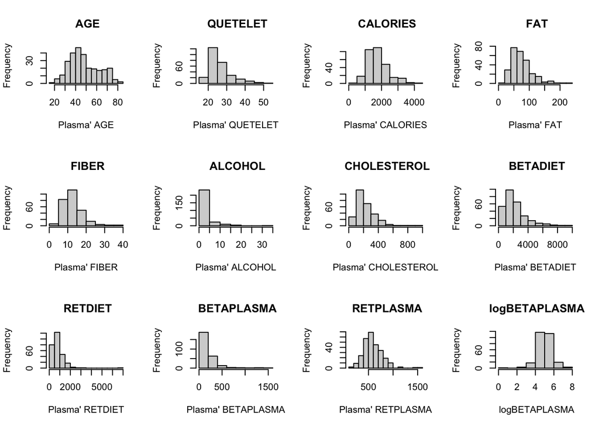

```r
par(mfrow = c(3,4))


for(i in 1:14) {
  if (i != 2 && i != 3 && i!= 5 ) {
hist(plasma[, i], main=paste("", names(plasma)[i]), xlab = paste('Plasma\'', names(plasma)[i]))}}

for(i in 15:22) {
hist(plasma[, i], main=paste("", names(plasma)[i]), xlab = paste('', names(plasma)[i]))}
```

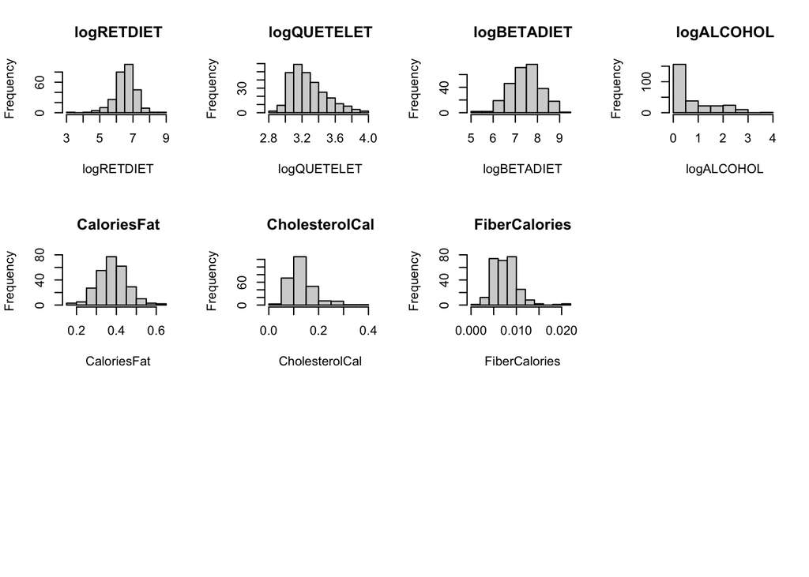

```r
par(mfrow = c(1,3))
```

```r
n <- nrow(plasma)
vals =
lbls <- c('FEMALE','MALE')
pct <- round(100*table(plasma$SEX)/n)
lab <- paste(lbls,pct)
lab <- paste(lab,'%',sep='')
lab
```

```
## [1] "FEMALE 100%" "MALE 0%"
```

```r
pie(table(plasma$SEX),labels=lab,col=c('blue','purple','green','yellow','orange'),
main='Sex: pie chart with percentage')


n <- nrow(plasma)
vals =
lbls <- c('FORMER','NEVER','CURRENT')
pct <- round(100*table(plasma$SMOKSTAT)/n)
lab <- paste(lbls,pct)
lab <- paste(lab,'%',sep='')
lab
```

```
## [1] "FORMER 13%"  "NEVER 34%"   "CURRENT 53%"
```

```r
pie(table(plasma$SMOKSTAT),labels=lab,col=c('blue','purple','green','yellow','orange'),
main='SMOKSTAT: pie chart with percentage')


n <- nrow(plasma)
vals =
lbls <- c('OFTEN','NOT OFTEN','NO')
pct <- round(100*table(plasma$VITUSE)/n)
lab <- paste(lbls,pct)
lab <- paste(lab,'%',sep='')
lab
```

```
## [1] "OFTEN 32%"     "NOT OFTEN 28%" "NO 40%"
```

[figure not shown]

```r
pie(table(plasma$VITUSE),labels=lab,col=c('blue','purple','green','yellow','orange'),
main='VITAMIN USE: pie chart')
```

We then obtain the scatterplot matrix and box plots of categorical values compared to response variables.

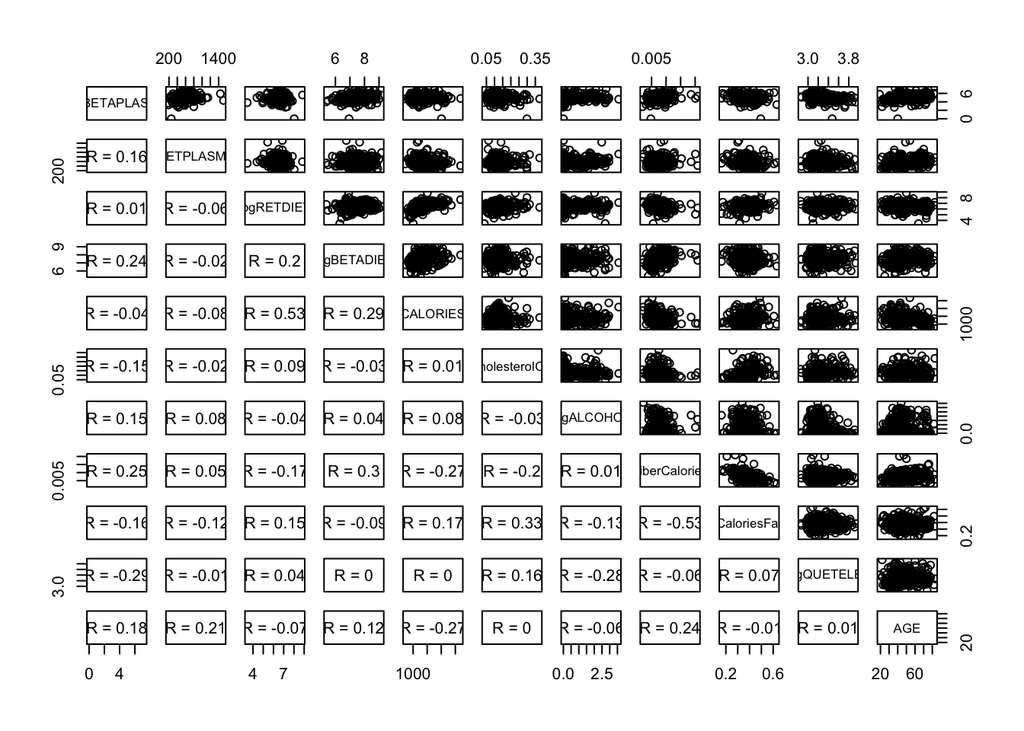

```r
panel.cor <- function(x, y){
  par(usr = c(0, 1, 0, 1))
  r <- round(cor(x, y, use="complete.obs"), 2)
  txt <- paste0("R = ", r)
  text(0.5, 0.5, txt)
}

pairs(~logBETAPLASMA+RETPLASMA+logRETDIET+logBETADIET+CALORIES+CholesterolCal+logALCOHOL+FiberCalories+CaloriesFat+logQUETELET+AGE, data=plasma, lower.panel = panel.cor)
```

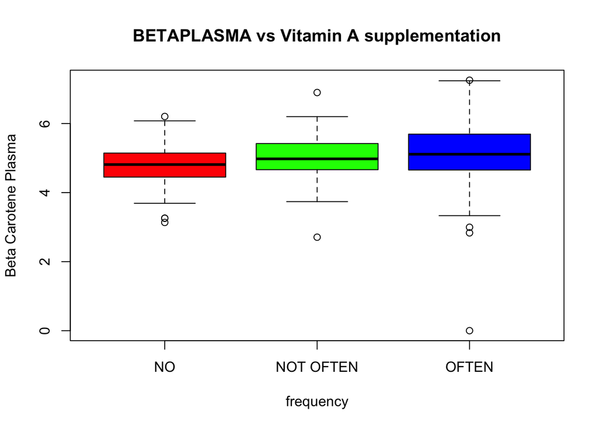

```r
boxplot(plasma$logBETAPLASMA~plasma$VITUSE,main='BETAPLASMA vs Vitamin A supplementation',
xlab='frequency',ylab='Beta Carotene Plasma',col=rainbow(3))
```

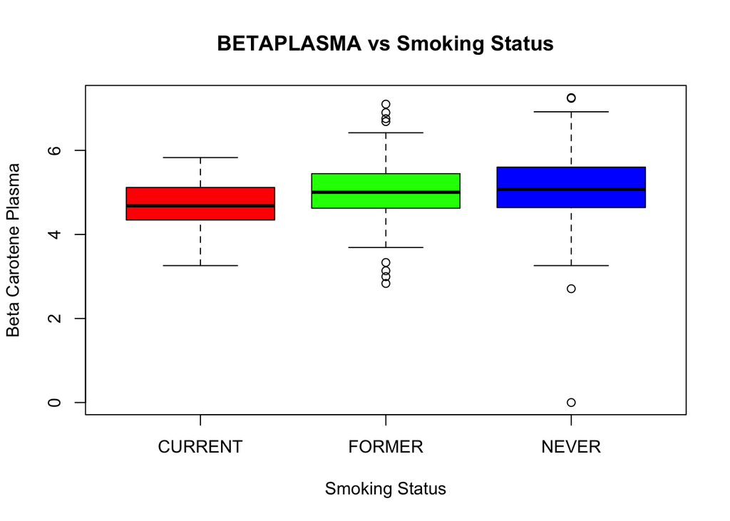

```r
boxplot(plasma$logBETAPLASMA~plasma$SMOKSTAT,main='BETAPLASMA vs Smoking Status',
xlab='Smoking Status',ylab='Beta Carotene Plasma',col=rainbow(3))
```

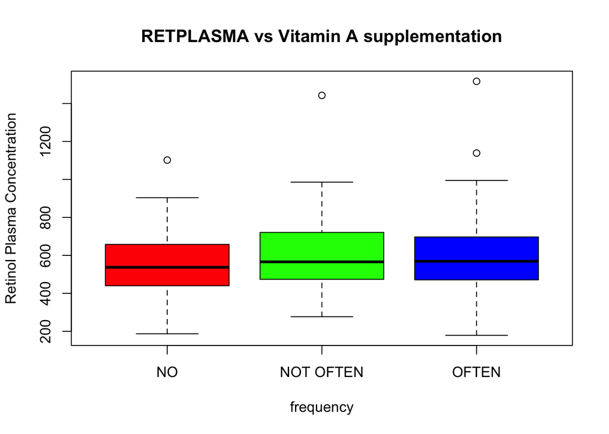

```r
boxplot(plasma$RETPLASMA~plasma$VITUSE,main='RETPLASMA vs Vitamin A supplementation',
xlab='frequency',ylab='Retinol Plasma Concentration',col=rainbow(3))
```

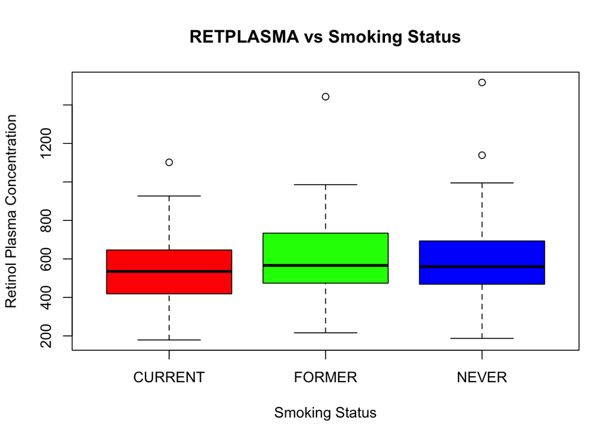

```r
boxplot(plasma$RETPLASMA~plasma$SMOKSTAT,main='RETPLASMA vs Smoking Status',
xlab='Smoking Status',ylab='Retinol Plasma Concentration',col=rainbow(3))
```

```r
#cor(plasma[, c("logBETAPLASMA", "RETPLASMA", "logRETDIET","logBETADIET","CholestrolCaloryProportion","logALCOHOL","FiberCaloryProportion","percentCaloriesFat","logQUETELET","AGE")])
```

REGRESSION FOR PLASMA BETA-CAROTENE First, we need to create a subset of the plasma dataset, removing variables we’ve transformed, retplasma, as well as the sex variable, as only women remain in the dataset. Then, we will set up our stepwise regression by creating a null model (logBETAPLASMA regressed onto 1) and our full model (logBETAPLASMA regressed onto all remaining variables.)

```r
betaplasma<- subset(plasma, select = -c(FAT, FIBER, CHOLESTEROL, BETAPLASMA, RETDIET, QUETELET, BETADIET, ALCOHOL,RETPLASMA, SEX ))
betaplasma<-betaplasma[betaplasma$logBETAPLASMA > 0,]
nullbpmodel<- lm(logBETAPLASMA ~1, data=betaplasma)
fullbpmodel<-lm(logBETAPLASMA ~., data = betaplasma)
```

Now, we run our stepwise regression, going in both directions from both the null and full model.

```r
stepbeta<-step(fullbpmodel, direction = 'both')
```

```
## Start:  AIC=-222.22
## logBETAPLASMA ~ AGE + SMOKSTAT + VITUSE + CALORIES + logRETDIET +
##     logQUETELET + logBETADIET + logALCOHOL + CaloriesFat + CholesterolCal +
##     FiberCalories
##
##                  Df Sum of Sq    RSS     AIC
## - CholesterolCal  1    0.0000 108.41 -224.22
## - CaloriesFat     1    0.0195 108.42 -224.17
## - CALORIES        1    0.1682 108.57 -223.80
## - logRETDIET      1    0.7331 109.14 -222.39
## <none>                        108.41 -222.22
## - AGE             1    1.1299 109.53 -221.40
## - logALCOHOL      1    1.2331 109.64 -221.14
## - FiberCalories   1    1.4700 109.88 -220.56
## - logBETADIET     1    2.0068 110.41 -219.23
## - VITUSE          2    3.0823 111.49 -218.59
## - SMOKSTAT        2    3.3776 111.78 -217.88
## - logQUETELET     1    9.4887 117.89 -201.40
##
## Step:  AIC=-224.22
## logBETAPLASMA ~ AGE + SMOKSTAT + VITUSE + CALORIES + logRETDIET +
##     logQUETELET + logBETADIET + logALCOHOL + CaloriesFat + FiberCalories
##
##                  Df Sum of Sq    RSS     AIC
## - CaloriesFat     1    0.0212 108.43 -226.17
## - CALORIES        1    0.1707 108.58 -225.79
## - logRETDIET      1    0.7372 109.14 -224.38
## <none>                        108.41 -224.22
## - AGE             1    1.1299 109.53 -223.40
## - logALCOHOL      1    1.2410 109.65 -223.12
## - FiberCalories   1    1.4731 109.88 -222.55
## + CholesterolCal  1    0.0000 108.41 -222.22
## - logBETADIET     1    2.0146 110.42 -221.21
## - VITUSE          2    3.0859 111.49 -220.59
## - SMOKSTAT        2    3.3891 111.79 -219.85
## - logQUETELET     1    9.7112 118.12 -202.88
##
## Step:  AIC=-226.17
## logBETAPLASMA ~ AGE + SMOKSTAT + VITUSE + CALORIES + logRETDIET +
##     logQUETELET + logBETADIET + logALCOHOL + FiberCalories
```

[output cut: 35 more lines]

```
##     logALCOHOL + FiberCalories
##
##                  Df Sum of Sq    RSS     AIC
## <none>                        109.17 -228.30
## + logRETDIET      1    0.5798 108.59 -227.75
## - logALCOHOL      1    1.0846 110.26 -227.61
## - AGE             1    1.4721 110.64 -226.66
## + CaloriesFat     1    0.0300 109.14 -226.38
## + CholesterolCal  1    0.0114 109.16 -226.33
## + CALORIES        1    0.0003 109.17 -226.30
## - FiberCalories   1    1.8298 111.00 -225.78
## - VITUSE          2    3.1484 112.32 -224.57
## - logBETADIET     1    2.6629 111.84 -223.75
## - SMOKSTAT        2    3.5730 112.75 -223.54
## - logQUETELET     1    9.7222 118.89 -207.10
```

```r
stepbetaforward<-step(nullbpmodel, scope = logBETAPLASMA~AGE + SMOKSTAT + VITUSE +CALORIES + logRETDIET + logQUETELET + logBETADIET + logALCOHOL +CaloriesFat + CholesterolCal +FiberCalories, direction = 'both')
```

```
## Start:  AIC=-170.1
## logBETAPLASMA ~ 1
##
##                  Df Sum of Sq    RSS     AIC
## + logQUETELET     1   12.6876 131.78 -193.10
## + logBETADIET     1    8.4496 136.02 -184.50
## + FiberCalories   1    8.4139 136.06 -184.42
## + VITUSE          2    6.8949 137.57 -179.40
## + SMOKSTAT        2    6.1863 138.28 -178.01
## + AGE             1    4.5972 139.87 -176.90
## + logALCOHOL      1    2.9049 141.56 -173.63
## + CaloriesFat     1    2.7608 141.71 -173.35
## <none>                        144.47 -170.10
## + CholesterolCal  1    0.9258 143.54 -169.85
## + logRETDIET      1    0.8187 143.65 -169.65
## + CALORIES        1    0.0042 144.47 -168.11
##
## Step:  AIC=-193.1
## logBETAPLASMA ~ logQUETELET
##
##                  Df Sum of Sq    RSS     AIC
## + logBETADIET     1    8.4325 123.35 -209.09
## + SMOKSTAT        2    8.8714 122.91 -208.06
## + FiberCalories   1    7.3125 124.47 -206.63
## + AGE             1    4.7768 127.01 -201.15
## + VITUSE          2    5.4032 126.38 -200.49
## + CaloriesFat     1    2.0064 129.78 -195.28
## + logRETDIET      1    1.0124 130.77 -193.20
## <none>                        131.78 -193.10
## + logALCOHOL      1    0.5758 131.21 -192.30
## + CholesterolCal  1    0.1773 131.60 -191.47
## + CALORIES        1    0.0022 131.78 -191.11
## - logQUETELET     1   12.6876 144.47 -170.10
##
## Step:  AIC=-209.09
## logBETAPLASMA ~ logQUETELET + logBETADIET
##
##                  Df Sum of Sq    RSS     AIC
## + SMOKSTAT        2    6.5366 116.81 -219.90
## + FiberCalories   1    3.6640 119.69 -215.29
```

[output cut: 83 more lines]

```
##     VITUSE + AGE + logALCOHOL
##
##                  Df Sum of Sq    RSS     AIC
## <none>                        109.17 -228.30
## + logRETDIET      1    0.5798 108.59 -227.75
## - logALCOHOL      1    1.0846 110.26 -227.61
## - AGE             1    1.4721 110.64 -226.66
## + CaloriesFat     1    0.0300 109.14 -226.38
## + CholesterolCal  1    0.0114 109.16 -226.33
## + CALORIES        1    0.0003 109.17 -226.30
## - FiberCalories   1    1.8298 111.00 -225.78
## - VITUSE          2    3.1484 112.32 -224.57
## - logBETADIET     1    2.6629 111.84 -223.75
## - SMOKSTAT        2    3.5730 112.75 -223.54
## - logQUETELET     1    9.7222 118.89 -207.10
```

As we can see from above, our stepwise procedures have both arrived at the same model. We obtain the model’s summary statistics.

```r
summary(stepbeta)
```

```
##
## Call:
## lm(formula = logBETAPLASMA ~ AGE + SMOKSTAT + VITUSE + logQUETELET +
##     logBETADIET + logALCOHOL + FiberCalories, data = betaplasma)
##
## Residuals:
##      Min       1Q   Median       3Q      Max
## -1.95828 -0.36675 -0.01492  0.38350  1.75245
##
## Coefficients:
##                  Estimate Std. Error t value Pr(>|t|)
## (Intercept)      5.975304   0.787741   7.585 5.79e-13 ***
## AGE              0.005496   0.002924   1.880  0.06128 .
## SMOKSTATFORMER   0.268962   0.131605   2.044  0.04198 *
## SMOKSTATNEVER    0.369977   0.127026   2.913  0.00389 **
## VITUSENOT OFTEN  0.223249   0.101681   2.196  0.02900 *
## VITUSEOFTEN      0.244807   0.097045   2.523  0.01224 *
## logQUETELET     -0.964101   0.199594  -4.830 2.32e-06 ***
## logBETADIET      0.156721   0.061994   2.528  0.01206 *
## logALCOHOL       0.079343   0.049179   1.613  0.10787
## FiberCalories   33.383963  15.930983   2.096  0.03708 *
## ---
## Signif. codes:  0 '***' 0.001 '**' 0.01 '*' 0.05 '.' 0.1 ' ' 1
##
## Residual standard error: 0.6455 on 262 degrees of freedom
## Multiple R-squared:  0.2443, Adjusted R-squared:  0.2184
## F-statistic: 9.412 on 9 and 262 DF,  p-value: 2.122e-12
```

From the above model, we can see we cannot reject the possibility age and alcohol consumption are statistically insignificant at the 95% confidence level. Therefore, we will remove them from our final model.

```r
finalbetaplasmamodel<-lm(betaplasma$logBETAPLASMA ~ SMOKSTAT + VITUSE + logQUETELET + logBETADIET + FiberCalories, data = betaplasma)

summary(finalbetaplasmamodel)
```

```
##
## Call:
## lm(formula = betaplasma$logBETAPLASMA ~ SMOKSTAT + VITUSE + logQUETELET +
##     logBETADIET + FiberCalories, data = betaplasma)
##
## Residuals:
##      Min       1Q   Median       3Q      Max
## -2.04996 -0.38400 -0.01627  0.36783  1.84821
##
## Coefficients:
##                 Estimate Std. Error t value Pr(>|t|)
## (Intercept)      6.46087    0.76046   8.496 1.45e-15 ***
## SMOKSTATFORMER   0.31196    0.13133   2.375  0.01824 *
## SMOKSTATNEVER    0.40187    0.12689   3.167  0.00172 **
## VITUSENOT OFTEN  0.20711    0.10209   2.029  0.04350 *
## VITUSEOFTEN      0.22802    0.09638   2.366  0.01871 *
## logQUETELET     -1.05273    0.19206  -5.481 9.86e-08 ***
## logBETADIET      0.16557    0.06233   2.656  0.00838 **
## FiberCalories   38.77608   15.75574   2.461  0.01449 *
## ---
## Signif. codes:  0 '***' 0.001 '**' 0.01 '*' 0.05 '.' 0.1 ' ' 1
##
## Residual standard error: 0.6503 on 264 degrees of freedom
## Multiple R-squared:  0.2273, Adjusted R-squared:  0.2068
## F-statistic:  11.1 on 7 and 264 DF,  p-value: 2.689e-12
```

QQ-Plot and Fitted Values Plot for finalbetaplasma model

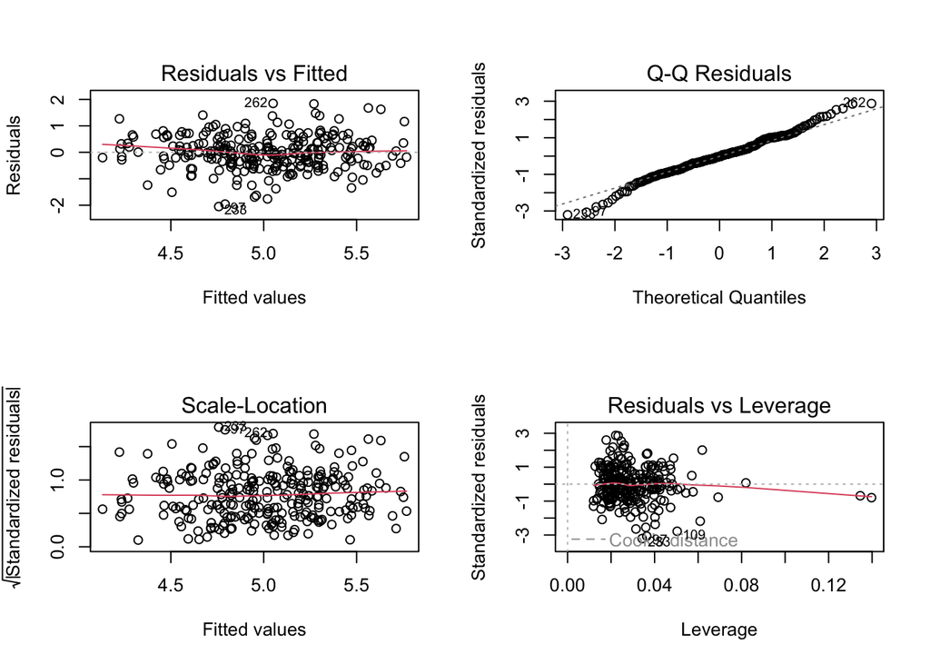

```r
par(mfrow= c(2,2))
plot(finalbetaplasmamodel)
```

RETINOL PLASMA MODEL

Since this model will focus on Retinol Plasma levels as the response variable, we are trimming the inital dataset in terms of variable scope. The variables to be removed include: the categorical variable ‘Sex’ since there is only one factor level remaining now that we have removed the males, the original versions of the transformed variables (Retdiet, Quetelet, Betadiet, Fat, Fiber, Cholesterol, Alcohol), and lastly the alternate response variable to be examined in our other model (Betaplasma, logBetaplasma.) We then use the trimmed data set to fit an initial first-order regression model.

```r
ret_plasma_reduced <- subset(plasma, select = -c(SEX, BETAPLASMA, logBETAPLASMA, RETDIET, QUETELET, BETADIET, FAT, FIBER, CHOLESTEROL, ALCOHOL))
initial_fit <- lm(formula = RETPLASMA ~ ., data = ret_plasma_reduced)
```

```r
summary(initial_fit)
```

```
##
## Call:
## lm(formula = RETPLASMA ~ ., data = ret_plasma_reduced)
##
## Residuals:
##     Min      1Q  Median      3Q     Max
## -381.09 -120.23  -32.22   95.89  909.21
##
## Coefficients:
##                   Estimate Std. Error t value Pr(>|t|)
## (Intercept)      6.721e+02  2.579e+02   2.606 0.009692 **
## AGE              3.217e+00  8.625e-01   3.730 0.000235 ***
## SMOKSTATFORMER   3.378e+01  3.722e+01   0.908 0.364915
## SMOKSTATNEVER    1.986e+00  3.588e+01   0.055 0.955889
## VITUSENOT OFTEN  4.295e+01  2.891e+01   1.486 0.138565
## VITUSEOFTEN      2.935e+01  2.769e+01   1.060 0.290040
## CALORIES         2.906e-04  2.391e-02   0.012 0.990314
## logRETDIET      -9.308e+00  2.103e+01  -0.443 0.658415
## logQUETELET      1.405e+01  5.671e+01   0.248 0.804490
## logBETADIET     -1.361e+01  1.916e+01  -0.711 0.478020
## logALCOHOL       1.576e+01  1.410e+01   1.118 0.264779
## CaloriesFat     -3.727e+02  1.885e+02  -1.977 0.049114 *
## CholesterolCal   7.395e+01  2.299e+02   0.322 0.748013
## FiberCalories   -5.317e+03  5.547e+03  -0.958 0.338719
## ---
## Signif. codes:  0 '***' 0.001 '**' 0.01 '*' 0.05 '.' 0.1 ' ' 1
##
## Residual standard error: 181.3 on 259 degrees of freedom
## Multiple R-squared:  0.0898, Adjusted R-squared:  0.04412
## F-statistic: 1.966 on 13 and 259 DF,  p-value: 0.02393
```

```r
anova(initial_fit)
```

```
## Analysis of Variance Table
##
## Response: RETPLASMA
##                 Df  Sum Sq Mean Sq F value    Pr(>F)
## AGE              1  426846  426846 12.9868 0.0003761 ***
## SMOKSTAT         2   65050   32525  0.9896 0.3731343
## VITUSE           2   94038   47019  1.4306 0.2410595
## CALORIES         1   13786   13786  0.4194 0.5177874
## logRETDIET       1   13775   13775  0.4191 0.5179604
## logQUETELET      1     517     517  0.0157 0.9002748
## logBETADIET      1   24152   24152  0.7348 0.3921197
## logALCOHOL       1   71980   71980  2.1900 0.1401243
## CaloriesFat      1   95266   95266  2.8985 0.0898630 .
## CholesterolCal   1    4289    4289  0.1305 0.7182191
## FiberCalories    1   30194   30194  0.9187 0.3387185
## Residuals      259 8512702   32868
## ---
## Signif. codes:  0 '***' 0.001 '**' 0.01 '*' 0.05 '.' 0.1 ' ' 1
```

Looking at these results from the initial model, we can see that the summary table indicates that the coefficients for the age and CaloriesFat variables are both significantly different from 0 albeit at varying alpha levels (~0 and 0.05, respectively.) Additionally, note the adjusted R-squared of 0.04412 which appears quite low at first glance. Switching gears to the ANOVA table for the initial model, it shows age as a variable that significantly improves the model as well a CaloriesFat which also improves the model albeit much less significantly.

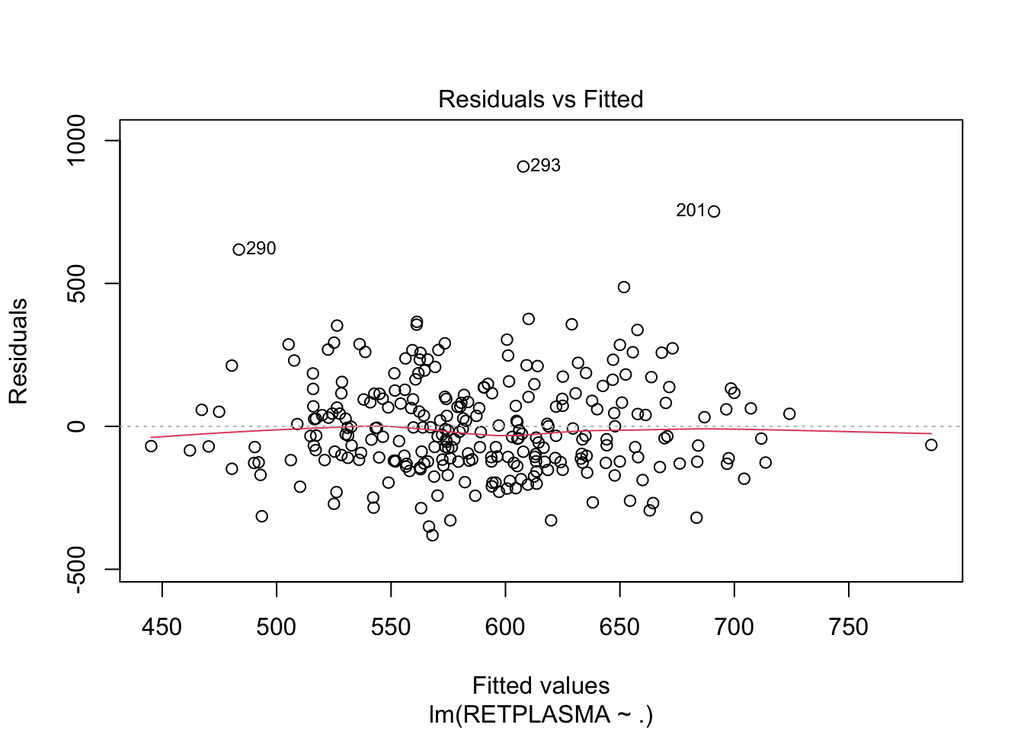

```r
plot(initial_fit, which=1)
```

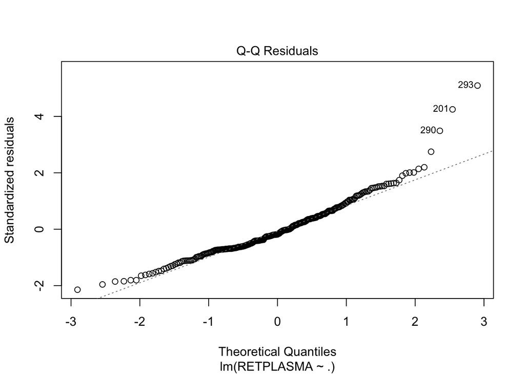

```r
plot(initial_fit, which=2)
```

Next, we examine the fitted values vs. residuals plot as well as the QQ plot. The points on the fitted vs. residuals plot are generally randomly scattered with no real discernible pattern indicating linearity of the model and somewhat constant variance. There are 3 outliers that show up in the QQ plot, giving it a sharp upward curve/heavy tail on the upper right end. They are all well above the main cluster however they are pretty evenly spread across the range of fitted values.

-Do something about it? (Transform Y, remove outliers from dataset?)

```r
ret_plasma_reduced[order(ret_plasma_reduced$RETPLASMA, decreasing = TRUE),]
```

[output not shown]

[output cut: 533 more lines]

Next we will run forward stepwise regression, backward stepwise forward selection and backwards elimination based on AIC and compare the final models.

```r
base_mod <- lm(RETPLASMA ~ 1, data = ret_plasma_reduced)
full_mod <- initial_fit
library(MASS)

# forward selection (AIC)
stepAIC(base_mod, scope = list(upper = full_mod, lower = ~1), direction = "forward",
    k = 2, trace = FALSE)
```

```
##
## Call:
## lm(formula = RETPLASMA ~ AGE + CaloriesFat + FiberCalories, data = ret_plasma_reduced)
##
## Coefficients:
##   (Intercept)            AGE    CaloriesFat  FiberCalories
##       657.117          3.125       -437.963      -7238.615
```

```r
# backward elimination based on AIC
stepAIC(full_mod, scope = list(upper = full_mod, lower = ~1), direction = "backward",
    k = 2, trace = FALSE)
```

```
##
## Call:
## lm(formula = RETPLASMA ~ AGE + CaloriesFat + FiberCalories, data = ret_plasma_reduced)
##
## Coefficients:
##   (Intercept)            AGE    CaloriesFat  FiberCalories
##       657.117          3.125       -437.963      -7238.615
```

```r
# forward stepwise based on AIC
stepAIC(base_mod, scope = list(upper = full_mod, lower = ~1), direction = "both",
    k = 2, trace = FALSE)
```

```
##
## Call:
## lm(formula = RETPLASMA ~ AGE + CaloriesFat + FiberCalories, data = ret_plasma_reduced)
##
## Coefficients:
##   (Intercept)            AGE    CaloriesFat  FiberCalories
##       657.117          3.125       -437.963      -7238.615
```

```r
# backward stepwise based on AIC
stepAIC(full_mod, scope = list(upper = full_mod, lower = ~1), direction = "both",
    k = 2, trace = FALSE)
```

```
##
## Call:
## lm(formula = RETPLASMA ~ AGE + CaloriesFat + FiberCalories, data = ret_plasma_reduced)
##
## Coefficients:
##   (Intercept)            AGE    CaloriesFat  FiberCalories
##       657.117          3.125       -437.963      -7238.615
```

```r
# forward selection based on BIC: set option 'k=log(n)'
stepAIC(base_mod, scope = list(upper = full_mod, lower = ~1), direction = "forward",
    k = log(n), trace = FALSE)
```

```
##
## Call:
## lm(formula = RETPLASMA ~ AGE, data = ret_plasma_reduced)
##
## Coefficients:
## (Intercept)          AGE
##     451.265        2.811
```

```r
# backward elimination based on BIC
stepAIC(full_mod, scope = list(upper = full_mod, lower = ~1), direction = "backward",
    k = log(n), trace = FALSE)
```

```
##
## Call:
## lm(formula = RETPLASMA ~ AGE, data = ret_plasma_reduced)
##
## Coefficients:
## (Intercept)          AGE
##     451.265        2.811
```

```r
# forward stepwise based on BIC
stepAIC(base_mod, scope = list(upper = full_mod, lower = ~1), direction = "both",
    k = log(n), trace = FALSE)
```

```
##
## Call:
## lm(formula = RETPLASMA ~ AGE, data = ret_plasma_reduced)
##
## Coefficients:
## (Intercept)          AGE
##     451.265        2.811
```

```r
# backward stepwise based on BIC
stepAIC(full_mod, scope = list(upper = full_mod, lower = ~1), direction = "both",
    k = log(n), trace = FALSE)
```

```
##
## Call:
## lm(formula = RETPLASMA ~ AGE, data = ret_plasma_reduced)
##
## Coefficients:
## (Intercept)          AGE
##     451.265        2.811
```

Based on AIC, the 4 main stepwise/selection variations all arrive at the same model that includes the predictor variables age, CaloriesFat, and FiberCalories whereas the stepwise variations using BIC as the criteria end up on a model that only contains age.

```r
AIC_stepwise_regression_model = lm(formula = RETPLASMA ~ AGE + CaloriesFat + FiberCalories, data = ret_plasma_reduced)
summary(AIC_stepwise_regression_model)
```

```
##
## Call:
## lm(formula = RETPLASMA ~ AGE + CaloriesFat + FiberCalories, data = ret_plasma_reduced)
##
## Residuals:
##     Min      1Q  Median      3Q     Max
## -439.56 -114.41  -20.43   99.96  893.52
##
## Coefficients:
##                 Estimate Std. Error t value Pr(>|t|)
## (Intercept)     657.1172    92.9618   7.069 1.35e-11 ***
## AGE               3.1253     0.8068   3.874 0.000135 ***
## CaloriesFat    -437.9626   174.7468  -2.506 0.012792 *
## FiberCalories -7238.6155  5017.5179  -1.443 0.150277
## ---
## Signif. codes:  0 '***' 0.001 '**' 0.01 '*' 0.05 '.' 0.1 ' ' 1
##
## Residual standard error: 180.1 on 269 degrees of freedom
## Multiple R-squared:  0.06745,    Adjusted R-squared:  0.05705
## F-statistic: 6.485 on 3 and 269 DF,  p-value: 0.000298
```

```r
anova(AIC_stepwise_regression_model)
```

```
## Analysis of Variance Table
##
## Response: RETPLASMA
##                Df  Sum Sq Mean Sq F value    Pr(>F)
## AGE             1  426846  426846 13.1649 0.0003413 ***
## CaloriesFat     1  136485  136485  4.2095 0.0411662 *
## FiberCalories   1   67482   67482  2.0813 0.1502772
## Residuals     269 8721783   32423
## ---
## Signif. codes:  0 '***' 0.001 '**' 0.01 '*' 0.05 '.' 0.1 ' ' 1
```

Comparing this output with that from the initial model, the summary table shows similar results but the p-value for the CaloriesFat variable is much lower (almost crossing into the threshold for alpha = 0.01 level significance.) Also noteworth is that the R-squared adjusted is actually marginally higher than that of the initial model even though the model includes way less variables, further validating the model selection process. The ANOVA table for the stepwise model also has a higher significance level for the CaloriesFat variable.

```r
AIC(AIC_stepwise_regression_model)
```

```
## [1] 3616.259
```

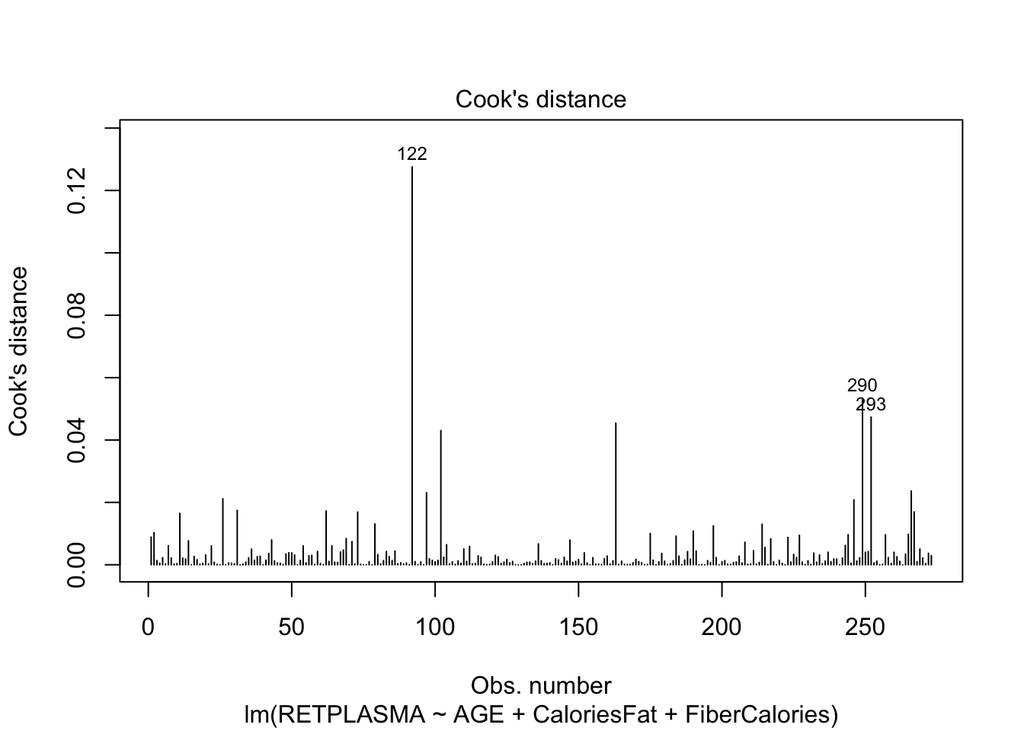

```r
ret_residuals <- AIC_stepwise_regression_model$residuals
plot(AIC_stepwise_regression_model, which=4)
```

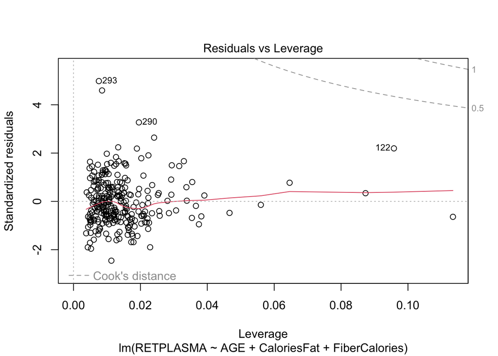

```r
plot(AIC_stepwise_regression_model, which=5)
```

```r
which(rownames(ret_plasma_reduced) == "122")
```

```
## [1] 92
```

```r
which(rownames(ret_plasma_reduced) == "290")
```

```
## [1] 249
```

```r
which(rownames(ret_plasma_reduced) == "293")
```

```
## [1] 252
```

```r
ret_plasma_reduced[92,]
```

```
##     AGE SMOKSTAT VITUSE CALORIES RETPLASMA logRETDIET logQUETELET logBETADIET
## 122  42  CURRENT  OFTEN   1084.3       927   5.075174    3.326801    7.963808
##     logALCOHOL CaloriesFat CholesterolCal FiberCalories
## 122  0.6931472   0.2091672     0.09748225    0.02010514
```

```r
ret_plasma_reduced[249,]
```

```
##     AGE SMOKSTAT VITUSE CALORIES RETPLASMA logRETDIET logQUETELET logBETADIET
## 290  36  CURRENT     NO   1959.3      1102   6.874198    3.286134    7.001246
##     logALCOHOL CaloriesFat CholesterolCal FiberCalories
## 290  0.4054651   0.5163068      0.1667432   0.003419589
```

```r
ret_plasma_reduced[252,]
```

```
##     AGE SMOKSTAT VITUSE CALORIES RETPLASMA logRETDIET logQUETELET logBETADIET
## 293  54    NEVER  OFTEN   1392.2      1517   6.870053    3.256364    6.745236
##     logALCOHOL CaloriesFat CholesterolCal FiberCalories
## 293          0   0.3090073     0.06285017    0.00926591
```

```r
fit.122 <- lm(AIC_stepwise_regression_model, data = ret_plasma_reduced, subset = setdiff(rownames(ret_plasma_reduced), "122"))  ##exclude case 122
print('Regression coefficients for full final model (row 1) and model excluding case 122 (row 2)')
```

```
## [1] "Regression coefficients for full final model (row 1) and model excluding case 122 (row 2)"
```

```r
rbind(AIC_stepwise_regression_model$coefficients, fit.122$coefficients)  ##compare fitted regression coefficients
```

```
##      (Intercept)      AGE CaloriesFat FiberCalories
## [1,]    657.1172 3.125318   -437.9626     -7238.615
## [2,]    674.0817 3.316628   -449.4251    -10343.096
```

```r
fit.290 <- lm(AIC_stepwise_regression_model, data= ret_plasma_reduced, subset = setdiff(rownames(ret_plasma_reduced), "290"))  ##exclude case 290
print('Regression coefficients for full final model (row 1) and model excluding case 290 (row 2)')
```

```
## [1] "Regression coefficients for full final model (row 1) and model excluding case 290 (row 2)"
```

```r
rbind(AIC_stepwise_regression_model$coefficients, fit.290$coefficients)  ##compare fitted regression coefficients
```

```
##      (Intercept)      AGE CaloriesFat FiberCalories
## [1,]    657.1172 3.125318   -437.9626     -7238.615
## [2,]    662.9790 3.241178   -482.9359     -6783.332
```

```r
fit.293 <- lm(AIC_stepwise_regression_model, data = ret_plasma_reduced, subset = setdiff(rownames(ret_plasma_reduced), "293"))  ##exclude case 290
print('Regression coefficients for full final model (row 1) and model excluding case 293 (row 2)')
```

```
## [1] "Regression coefficients for full final model (row 1) and model excluding case 293 (row 2)"
```

```r
rbind(AIC_stepwise_regression_model$coefficients, fit.293$coefficients)  ##compare fitted regression coefficients
```

```
##      (Intercept)      AGE CaloriesFat FiberCalories
## [1,]    657.1172 3.125318   -437.9626     -7238.615
## [2,]    643.1745 3.040020   -397.2487     -7330.665
```

```r
summary(fit.122)
```

```
##
## Call:
## lm(formula = AIC_stepwise_regression_model, data = ret_plasma_reduced,
##     subset = setdiff(rownames(ret_plasma_reduced), "122"))
##
## Residuals:
##     Min      1Q  Median      3Q     Max
## -444.66 -115.18  -22.67   99.47  898.53
##
## Coefficients:
##                 Estimate Std. Error t value Pr(>|t|)
## (Intercept)    6.741e+02  9.262e+01   7.278 3.75e-12 ***
## AGE            3.317e+00  8.057e-01   4.117 5.12e-05 ***
## CaloriesFat   -4.494e+02  1.736e+02  -2.589   0.0101 *
## FiberCalories -1.034e+04  5.176e+03  -1.998   0.0467 *
## ---
## Signif. codes:  0 '***' 0.001 '**' 0.01 '*' 0.05 '.' 0.1 ' ' 1
##
## Residual standard error: 178.8 on 268 degrees of freedom
## Multiple R-squared:  0.07269,    Adjusted R-squared:  0.06231
## F-statistic: 7.003 on 3 and 268 DF,  p-value: 0.0001498
```

```r
anova(fit.122)
```

```
## Analysis of Variance Table
##
## Response: RETPLASMA
##                Df  Sum Sq Mean Sq F value    Pr(>F)
## AGE             1  439819  439819 13.7610 0.0002524 ***
## CaloriesFat     1  103985  103985  3.2535 0.0723958 .
## FiberCalories   1  127632  127632  3.9933 0.0466910 *
## Residuals     268 8565626   31961
## ---
## Signif. codes:  0 '***' 0.001 '**' 0.01 '*' 0.05 '.' 0.1 ' ' 1
```